# Mini Project 2

Claire Burcik, Hannah Park, and Mia Iceland

2024-03-23

## Front Matter

```r
remove(list = ls())
library(kableExtra)
library(tidyverse)
library(readxl)

COD <- read_excel("CODGames2_mp.xlsx")
```

## Task 1

```r
COD_copy <- na.omit(COD)

rowSums(is.na(COD))
```

```
##   [1] 11 11 14 11 11 11 14 11 11  8  8 11 11 11 11 11  8 11  8  8 11 14 14 11 11
##  [26] 14 11 11 11 11 11 11 11  8  8  8 11 11 11 11 11 14 11 11 11 11 11 11 11 14
##  [51] 11 11 11 11 11 14 11 11 14 11 14 11 11 11 11 11 14 11 11 11 14 11 11 11 11
##  [76] 11 11 11 14 11 11 11 11 11 14 14 11 11 11 11 11 11 11 11 11 11 11 11 14 11
## [101] 11 11 11 11 11 11 11 11 14 11 11 11 11 11 11 11 11 11 14 11 11 11 14 11 11
## [126] 11 11 11 11 14 11 14 11 11 14 11 11 11 11 11 11 11 11 11 11 14 11 11 14 11
## [151] 11 11 14 11 14 11 11  8 11 14 11 11 11 11 11 11 11 11 11 11 14 14 11 11 11
## [176] 11 11 11 14 14 14 11 14 11 11 11 11 11 11 11 14 11 11 14 11 11 14 11 11 11
## [201] 11 11 11 11 11 11 11 11 14 15 11
```

A person should avoid using na.omit on rows in the COD data set because it omits all the rows. After summing up all the NA’s in each row, every row within the data set contain at least one NA. Since there is at least one NA in each row, all the rows got removed from the data set when na.omit was used. So, omitting the rows with NAs would cause the data set to be empty.

## Task 2

### Game Type

The variable GameType is a categorical variable that takes 4 different labels that represent the game modes one can play. The 4 game types are HC-Domination, HC-Hardpoint, HC-Kill Confirmed, and HC-TDM (Team Deathmatch). There is no missing data within the variable.

```r
#Count NA Values
sum(is.na(COD$GameType))
```

```
## [1] 0
```

```r
#Summary Statistic
GT_table <- table(COD$GameType)
prop_table <- GT_table / sum(GT_table)

prop_table%>% kbl(col.names = c("Game Type", "Proportions"))%>%
  kable_styling()
```

| Game Type | Proportions |
| --- | --- |
| HC - Domination | 0.0142180 |
| HC - Hardpoint | 0.0379147 |
| HC - Kill Confirmed | 0.0142180 |
| HC - TDM | 0.9336493 |

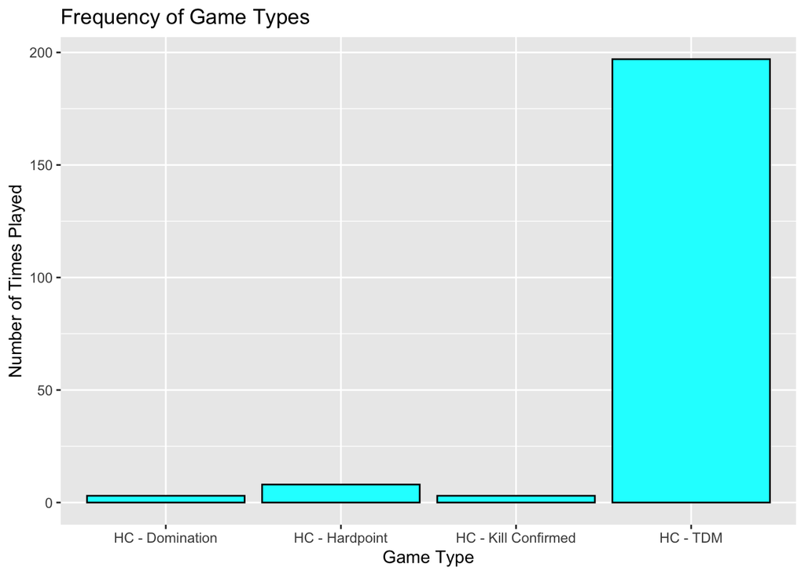

```r
# Visualization
ggplot(data= COD, mapping = aes(x = GameType))+
  geom_bar(color = "black", fill = "cyan")+
  labs(x = "Game Type",
       y = "Number of Times Played",
       title = "Frequency of Game Types")
```

Both the proportion table and visualization show that the player spent most of their time playing the Team Deathmatch game mode compared to the others. With a distribution that is severely skewed left and a proportion of about .934 (a little less than 200 games played) for the game type HC-TDM, it is apparent that the player favors Team Deathmatch over other game mode.

### Total XP

The variable TotalXP is a quantitative variable that takes numeric values that represent the total number of experience points earned in a match. Players can earn XP points in numerous ways including killing the enemy, assisting in an enemy kill, and completing challenges. There are no missing values in this variable.

```r
## Count number of NA values in Damage
sum(is.na(COD$TotalXP))
```

```
## [1] 0
```

```r
## Summary Statistics
COD %>%
  summarize(
    min = min(TotalXP),
    median= median(TotalXP),
    mean = mean(TotalXP),
    max = max(TotalXP),
    std = sd(TotalXP)
  )
```

```
## # A tibble: 1 × 5
##     min median   mean   max   std
##   <dbl>  <dbl>  <dbl> <dbl> <dbl>
## 1  1935  10328 11975. 43816 6167.
```

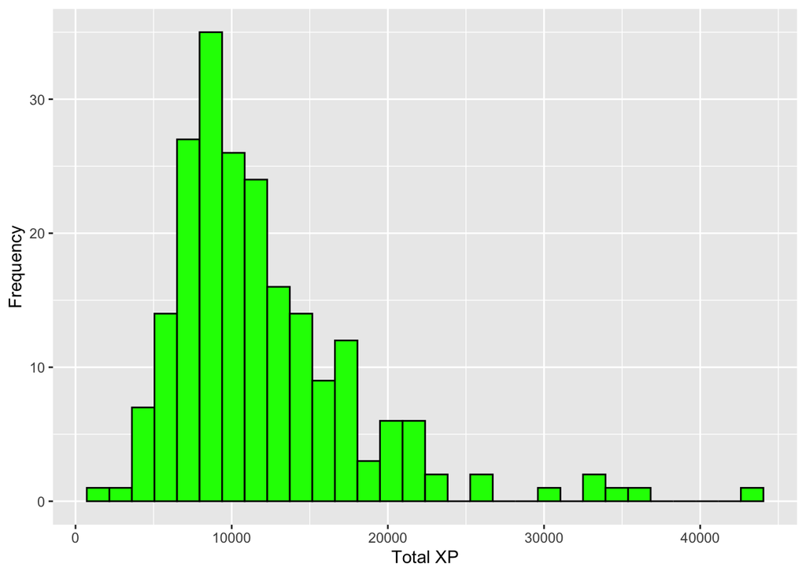

```r
# Visualization
ggplot(data= COD, mapping = aes(x = TotalXP))+
  geom_histogram(color = "black", fill = "green")+
  labs(x = "Total XP",
       y = "Frequency")
```

The histogram reveals that the player most often earns a total XP value within the range of about 3,500 to about 22,500. The mean value of 11975.4 XP and the median value of 10328 XP fit right into the middle of that range. Additionally, the mean being greater than the median is reflective of the right skewed distribution. The most frequent total XP value earned in a given match is around 9,000 experience points which occurred 35 times. The summary statistics also show that the lowest total XP that the player earned in a game was 1935 and the highest at 43816.

### Date

The variable ‘Date’ is a categorical variable that notes the month, day, and year of a match in Call of Duty. The dates range from June 2022 to August 2022. There are no missing values in the variable.

```r
## Count number of NA values in Date
sum(is.na(COD$Date))
```

```
## [1] 0
```

```r
## Summary Statistics
COD %>%
  summarize(
    min = min(Date),
    median= median(Date),
    mean = mean(Date),
    max = max(Date),
  )
```

```
## # A tibble: 1 × 4
##   min                 median              mean
##   <dttm>              <dttm>              <dttm>
## 1 2022-06-06 00:00:00 2022-07-04 00:00:00 2022-07-07 19:06:32
## # ℹ 1 more variable: max <dttm>
```

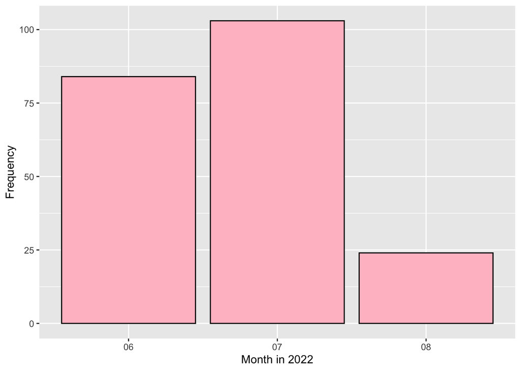

```r
## Visualization
COD1 <-
  COD %>%
  mutate(Date = as.character(Date),
         date_split = strsplit(Date, "-"),
         year = sapply(date_split, `[`, 1),
         month = sapply(date_split, `[`, 2),
         day = sapply(date_split, `[`, 3))


ggplot(data= COD1, mapping = aes(x = month)) +
  geom_bar(color = "black", fill = "pink") +
  labs(x = "Month in 2022",
       y = "Frequency")
```

Both the mean of 07/07/2022, median of 07/04/2022 and visualization show that the distribution of dates in which players play COD is slightly right-skewed. However, the general consensus is that most matches are played during July of 2022 with a frequency of over 100 matches. There is the consideration of constraints this data set has– was data only sample between the months of June to August of 2022 and does the frequency of player activity change if we had data from the whole year and/or for multiple years?

### Objective Kills

The variable Objective Kills is a quantitative variable in which each kill within the vicinity of a specific location are counted and earns points for a team. Whichever team with the most points wins the game. This only applies to games played in Hardpoint or Domination game mode. There are 200 missing values for this variable.

```r
## Count number of NA values in Objective Kills
sum(is.na(COD$ObjectiveKills))
```

```
## [1] 200
```

```r
## Remove NA values in Objective Kills
COD2 <-
  COD %>%
  filter(!is.na(ObjectiveKills))

## Summary Statistics
COD2 %>%
  summarize(
    count = n(),
    min = min(ObjectiveKills),
    median= median(ObjectiveKills),
    mean = mean(ObjectiveKills),
    max = max(ObjectiveKills),
    SD = sd(ObjectiveKills)
  )
```

```
## # A tibble: 1 × 6
##   count   min median  mean   max    SD
##   <int> <dbl>  <dbl> <dbl> <dbl> <dbl>
## 1    11     3      7  8.45    15  3.64
```

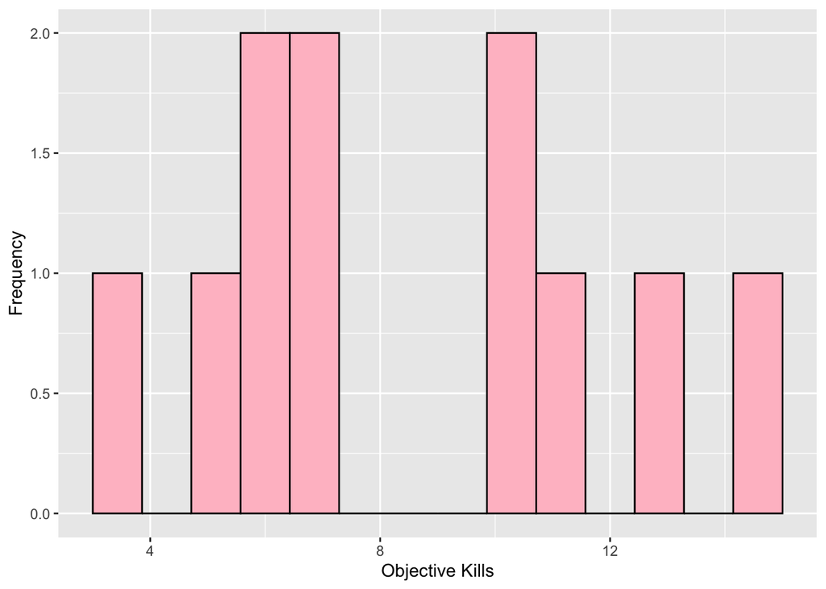

```r
## Visualization
ggplot(data= COD2, mapping = aes(x = ObjectiveKills)) +
  geom_histogram(color = "black", fill = "pink", bins = 15) +
  labs(x = "Objective Kills",
       y = "Frequency")
```

### XPType

In COD, XP is experience points. It helps players level up and is given from kills and other events. XPType includes the different types of boosts that would help to increase a player’s XP during a round/game. There are multiple ways to recieve these boosts and players are allowed to use these boosts within the game to gain more XP. The variable is qualitative and there are no missing variables within the XPType column.

```r
## Count number of NA values
sum(is.na(COD$XPType))
```

```
## [1] 0
```

```r
## Summary Statistics
XPT_table <- table(COD$XPType)
prop_table <- XPT_table / sum(XPT_table)

prop_table%>% kbl(col.names = c("XPType", "Proportions"))%>%
  kable_styling()
```

| XPType | Proportions |
| --- | --- |
| 10% Boost | 0.6113744 |
| Double XP + 10% | 0.3886256 |

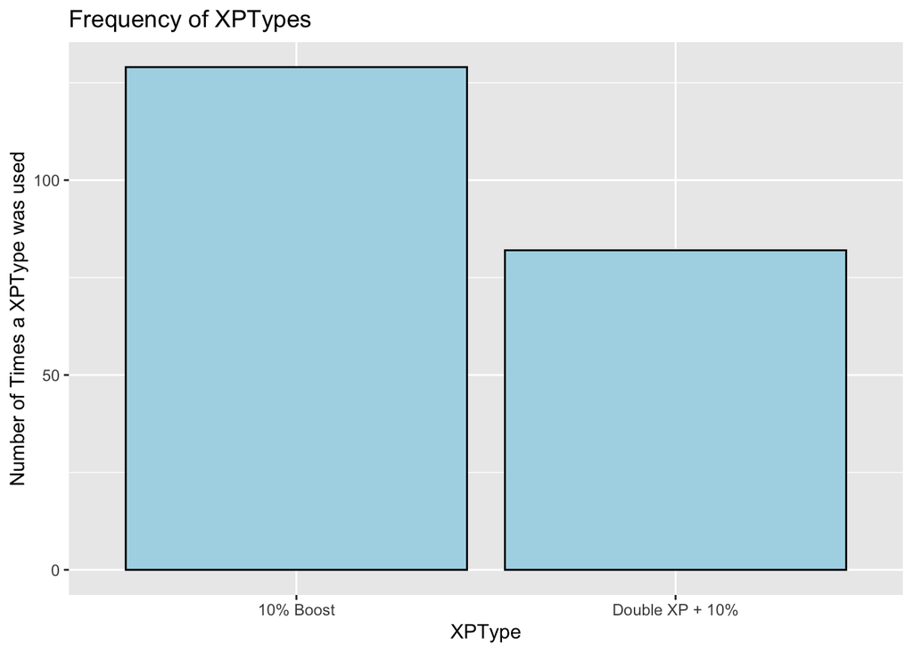

```r
ggplot(data= COD, mapping = aes(x = XPType))+
  geom_bar(color = "black", fill = "lightblue")+
  labs(x = "XPType",
       y = "Number of Times a XPType was used",
       title = "Frequency of XPTypes")
```

From the visualization, the player used the 10% boost on XP more than the Double XP + 10% boost. The 10% boost was used 129 times by the player while Double XP + 10% was used 82 times.

### Map1

In COD, Map1 is the first map the players play in during that round. The maps are the different environments the players play in every round, so the players have varied surroundings. This variable is qualitative and there are 43 missing values within the Map1 column.

```r
## Count number of NA values
sum(is.na(COD$Map1))
```

```
## [1] 43
```

```r
COD_Map1 <- COD %>%
  filter(Map1 != "NA")

## Summary Statistics
Map1_table <- table(COD_Map1$Map1)
prop_table <- Map1_table / sum(Map1_table)

prop_table%>% kbl(col.names = c("Map1_table", "Proportions"))%>%
  kable_styling()
```

| Map1_table | Proportions |
| --- | --- |
| Amerika | 0.0119048 |
| Apocalypse | 0.0595238 |
| Cartel | 0.0416667 |
| Checkmate | 0.0357143 |
| Collateral Strike | 0.0416667 |
| Crossroads Strike | 0.0357143 |
| Deprogram | 0.0357143 |
| Diesel | 0.0476190 |
| Drive-In | 0.0178571 |
| Echelon | 0.0535714 |
| Express | 0.0238095 |
| Garrison | 0.0476190 |
| Hijacked | 0.0297619 |
| Jungle | 0.0535714 |
| Miami Strike | 0.0238095 |
| Moscow | 0.0654762 |
| Nuketown ’84 | 0.0357143 |
| Raid | 0.0297619 |
| Ruah | 0.0059524 |
| Rush | 0.0476190 |
| Slums | 0.0297619 |
| Standoff | 0.0238095 |
| The Pines | 0.0714286 |
| WMD | 0.0416667 |
| Yamantau | 0.0297619 |
| Zoo | 0.0595238 |

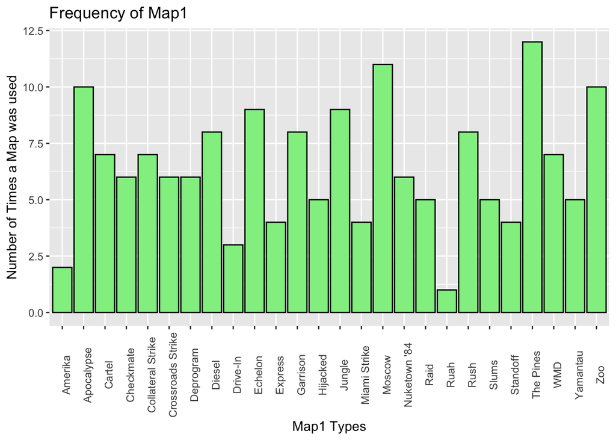

```r
ggplot(data= COD_Map1, mapping = aes(x = Map1))+
  geom_bar(color = "black", fill = "lightgreen")+
  labs(x = "Map1 Types",
       y = "Number of Times a Map was used",
       title = "Frequency of Map1")+
  theme(axis.text.x = element_text(angle = 90))
```

From this visualization, the player did not have a favorite map but did play around many of the maps. The most popular map was ‘The Pines’ and the least used map was ‘Ruah’. Removing the NAs made the graph easier to read and the y axis clearer. ‘The Pines’ map was played 12 times, while the ‘Ruah’ map was played 1 time by the player.

## Task 3

```r
COD <-
  COD %>%
  #Split string into two
  mutate (Result2 = strsplit(Result, "-"))

proportions <- function(df){
  countw <- 0
  countl <- 0
  countd <- 0
  for(i in 1:nrow(df)){
    #If first number > second number
    if (as.numeric(df$Result2[[i]][1]) > as.numeric(df$Result2[[i]][2])){
      #add t count of wins
      countw <- countw + 1
    }
    #if first number < second number
    else if (as.numeric(df$Result2[[i]][1]) < as.numeric(df$Result2[[i]][2])){
      #add to count of losses
      countl <- countl + 1
    }
    #if first number = second number
    else{
      #add to count of draws
      countd <- countd + 1
    }
  }
  prop_wins <- countw / nrow(df)
  prop_losses <- countl / nrow(df)
  prop_draws <- countd / nrow(df)
  return(lst(prop_wins, prop_losses, prop_draws))
}

proportions(COD)
```

```
## $prop_wins
## [1] 0.5402844
##
## $prop_losses
## [1] 0.4454976
##
## $prop_draws
## [1] 0.01421801
```

## Task 4

How does the variable ‘Eliminations’ affect whether the player’s team won the game?

```r
#Convert Result to indicator named outcome (Yes = 1, No = 0)
COD <-
  COD %>%
  #Split string into two
  mutate (Result2 = strsplit(Result, "-"))

  for(i in 1:nrow(COD)) {

  if (as.numeric(COD$Result2[[i]][1]) > as.numeric(COD$Result2[[i]][2])) {
    COD$outcome[i] <- 1
  }
    else {
    COD$outcome[i] <- 0
  }
}
#Build model with indicator as the response
model1 <-
  glm(outcome ~ Eliminations, family = binomial, data = COD)

#Display summary of model
summary(model1)
```

```
##
## Call:
## glm(formula = outcome ~ Eliminations, family = binomial, data = COD)
##
## Coefficients:
##              Estimate Std. Error z value Pr(>|z|)
## (Intercept)  -0.78078    0.38439  -2.031  0.04223 *
## Eliminations  0.06295    0.02413   2.609  0.00907 **
## ---
## Signif. codes:  0 '***' 0.001 '**' 0.01 '*' 0.05 '.' 0.1 ' ' 1
##
## (Dispersion parameter for binomial family taken to be 1)
##
##     Null deviance: 291.14  on 210  degrees of freedom
## Residual deviance: 283.89  on 209  degrees of freedom
## AIC: 287.89
##
## Number of Fisher Scoring iterations: 4
```

The estimated probability form is given by:

$$\hat{p}_i=\frac{e^{-0.78078 +
0.06295x_{i,elimination}}}{1+e^{-0.78078 +
0.06295x_{i,elimination}}}$$

Exponentiation:

$$e^\hat{β_i}={e^{0.06295}}={1.06497}$$

As the Elimination score increases by 1 point, we expect the odds of the player winning the game to change by a factor of 1.065. In other words, as the Elimination score increases by 1 point, we expect the odds of the player winning the game to increase by 6.5%.

## Group Contributions

### Claire

- Game Type and Total XP variable Exploration
- Task 3

### Mia

- Date and Objective Kills variable Exploration
- Task 4

### Hannah

- XPType and Map1 variable Exploration
- Task 1